# Problem set 3

Natalia Aristizábal

1/30/2019

Problem set 3: Structured population models Foundations of Quantitative Reasoning with Dr. Easton R. White

```r
# load packages
library(tidyverse)
library(popbio) # construction and analysis of matrix population models

plants <- load("~/Desktop/Quantitative_Reasoning/COMPADRE_v.4.0.1.RData")
# compadre$metadata$CommonName

animals <-load("~/Desktop/Quantitative_Reasoning/COMADRE_v.2.0.1.RData")
# comadre$metadata$CommonName

# to find strings text
grep(comadre$metadata$CommonName, pattern = "Cabbage aphid") # three different entries
```

```
## [1] 821 822 823
```

```r
# all entries come from the same publication: "Feeding location affects demographic performance of cabbage aphids on winter canola" by Ximena Cibils-Stewart1, Brett K. Sandercock2 & Brian P. McCornack

# explore one entry
comadre$metadata[821, ]
```

```
##             SpeciesAuthor       SpeciesAccepted    CommonName CoLCheckOK
## 821 Brevicoryne_brassicae Brevicoryne_brassicae Cabbage aphid       TRUE
##     CoLCheckDate Infraspecific SpeciesEpithetAccepted GenusAccepted
## 821     08082016          <NA>              brassicae   Brevicoryne
##     GenusAuthor    Family        Order   Class     Phylum  Kingdom
## 821 Brevicoryne Aphididae Aphidomorpha Insecta Arthropoda Animalia
##     OrganismType                               Authors          Journal
## 821      Insecta Ciblis-Stewart; Sandercock; McCornack Entomol Exp Appl
##     YearPublication          DOI.ISBN AdditionalSource StudyDuration
## 821            2015 10.1111/eea.12325             <NA>             2
##     StudyStart StudyEnd AnnualPeriodicity NumberPopulations
## 821       2011     2012               365                48
##     MatrixCriteriaSize MatrixCriteriaOntogeny MatrixCriteriaAge
## 821                 No                    Yes                No
##     MatrixPopulation Lat Lon Altitude Country Continent Ecoregion
## 821          Flowers  37 -98      459     USA N America       TGS
##     StudiedSex MatrixComposite           MatrixTreatment MatrixCaptivity
## 821          F            Mean Feeding location: Flowers              CW
##     MatrixStartYear MatrixStartSeason MatrixStartMonth MatrixEndYear
## 821            2012              <NA>               NA          2012
##     MatrixEndSeason MatrixEndMonth MatrixSplit MatrixFec Observation
## 821            <NA>             NA     Divided       Yes        <NA>
##     MatrixDimension SurvivalIssue
## 821               6             1
```

```r
# explore matrices
comadre$mat[821][[1]] # there are four matrices: matA, matU, matF, and matC
```

```
## $matA
##        A1   A2   A3   A4   A5   A6
## [1,] 0.32 0.00 0.00 0.00 3.25 0.00
## [2,] 0.60 0.30 0.00 0.00 0.00 0.00
## [3,] 0.00 0.57 0.41 0.00 0.00 0.00
## [4,] 0.00 0.00 0.41 0.49 0.00 0.00
## [5,] 0.00 0.00 0.00 0.37 0.95 0.00
## [6,] 0.00 0.00 0.00 0.00 0.05 0.74
##
## $matU
##        U1   U2   U3   U4   U5   U6
## [1,] 0.32 0.00 0.00 0.00 0.00 0.00
## [2,] 0.60 0.30 0.00 0.00 0.00 0.00
## [3,] 0.00 0.57 0.41 0.00 0.00 0.00
## [4,] 0.00 0.00 0.41 0.49 0.00 0.00
## [5,] 0.00 0.00 0.00 0.37 0.95 0.00
## [6,] 0.00 0.00 0.00 0.00 0.05 0.74
##
## $matF
##      F1 F2 F3 F4   F5 F6
## [1,]  0  0  0  0 3.25  0
## [2,]  0  0  0  0 0.00  0
## [3,]  0  0  0  0 0.00  0
## [4,]  0  0  0  0 0.00  0
## [5,]  0  0  0  0 0.00  0
## [6,]  0  0  0  0 0.00  0
##
## $matC
##      C1 C2 C3 C4 C5 C6
## [1,]  0  0  0  0  0  0
## [2,]  0  0  0  0  0  0
## [3,]  0  0  0  0  0  0
## [4,]  0  0  0  0  0  0
## [5,]  0  0  0  0  0  0
## [6,]  0  0  0  0  0  0
```

1. What species (and location if available) did you choose? Why did you choose the species?

I chose to work with the Cabbage aphid from the U.S. because understanding its population dynamics would be ecologically and economically important because they are a significant agricultural pest. Additionally, I have previous experience raising aphids in laboratory conditions and have seen their populations rapidly increase or die over a short period of time under stable environmental conditions and this would be a great chance to explore the mechanisms behind those population changes. Especially because you can tease apart mating resources in population dynamics since female aphdis clone themselves. Cabbage aphids are a good system to study predator-prey populations dynamics that I will be teaching soon in class and that are the base ecological models behind my research interests.

2. What question do you want to answer about this population (e.g. population status, best management strategies)?

I am interested in understanding strategies to manage aphid population’s rapid growth, thinking more in terms of biological control by predators than by inorganic pesticides. At which age stage is the cabbage aphid population growth more sensitive? I would like to know which age group is more vulnerable (to a predators or to an organic insecticide) and hence more effictively control the population.

3. Calculate eigenvalue, stable age distribution, elasticity, and sensitivity.

```r
aphids <- comadre$mat[821][[1]]$matA
print(aphids)
```

```
##        A1   A2   A3   A4   A5   A6
## [1,] 0.32 0.00 0.00 0.00 3.25 0.00
## [2,] 0.60 0.30 0.00 0.00 0.00 0.00
## [3,] 0.00 0.57 0.41 0.00 0.00 0.00
## [4,] 0.00 0.00 0.41 0.49 0.00 0.00
## [5,] 0.00 0.00 0.00 0.37 0.95 0.00
## [6,] 0.00 0.00 0.00 0.00 0.05 0.74
```

```r
# using eigen function in base R that "Computes eigenvalues and eigenvectors of numeric or complex matrices."

# calculate eignvalue, or population growth, for matA
eigen_value <- eigen(aphids)
print(eigen_value)
```

```
## eigen() decomposition
## $values
## [1]  1.2495593+0.0000000i  0.7116463+0.6237905i  0.7116463-0.6237905i
## [4]  0.7400000+0.0000000i -0.1014259+0.3959322i -0.1014259-0.3959322i
##
## $vectors
##                [,1]                      [,2]                      [,3]
## [1,] -0.76260009+0i  0.659430571+0.000000000i  0.659430571+0.000000000i
## [2,] -0.48186570+0i  0.291587613-0.441858904i  0.291587613+0.441858904i
## [3,] -0.32715194+0i -0.222810614-0.374188032i -0.222810614+0.374188032i
## [4,] -0.17659226+0i -0.264575566+0.052437732i -0.264575566-0.052437732i
## [5,] -0.21811754+0i  0.079465704+0.126568160i  0.079465704-0.126568160i
## [6,] -0.02140257+0i  0.009835243-0.006816633i  0.009835243+0.006816633i
##      [,4]                     [,5]                     [,6]
## [1,] 0+0i -0.389827486+0.38449248i -0.389827486-0.38449248i
## [2,] 0+0i  0.582664117+0.00000000i  0.582664117+0.00000000i
## [3,] 0+0i -0.406039696-0.31434501i -0.406039696+0.31434501i
## [4,] 0+0i  0.093634103+0.28060015i  0.093634103-0.28060015i
## [5,] 0+0i  0.003707834-0.09734780i  0.003707834+0.09734780i
## [6,] 1+0i -0.002408934+0.00465117i -0.002408934-0.00465117i
```

```r
# all eigen values
eigen_value$values
```

```
## [1]  1.2495593+0.0000000i  0.7116463+0.6237905i  0.7116463-0.6237905i
## [4]  0.7400000+0.0000000i -0.1014259+0.3959322i -0.1014259-0.3959322i
```

```r
# extracting highest - or dominant - eigen value
eigen_value$values[1]
```

```
## [1] 1.249559+0i
```

```r
# The dominant eigenvalue determines population growth
# 1.24, means this population of Cabbage aphids is exponentially growing

# all eigen vectors
eigen_value$vectors # remembering that the number of columns are the number of age groups, so in this Cabbage aphid population there are 6 age groups which are as follows: four nymphal stages (1st-4th instars) and two adult stages (5th instar reproductive and post-reprodcutive).
```

```
##                [,1]                      [,2]                      [,3]
## [1,] -0.76260009+0i  0.659430571+0.000000000i  0.659430571+0.000000000i
## [2,] -0.48186570+0i  0.291587613-0.441858904i  0.291587613+0.441858904i
## [3,] -0.32715194+0i -0.222810614-0.374188032i -0.222810614+0.374188032i
## [4,] -0.17659226+0i -0.264575566+0.052437732i -0.264575566-0.052437732i
## [5,] -0.21811754+0i  0.079465704+0.126568160i  0.079465704-0.126568160i
## [6,] -0.02140257+0i  0.009835243-0.006816633i  0.009835243+0.006816633i
##      [,4]                     [,5]                     [,6]
## [1,] 0+0i -0.389827486+0.38449248i -0.389827486-0.38449248i
## [2,] 0+0i  0.582664117+0.00000000i  0.582664117+0.00000000i
## [3,] 0+0i -0.406039696-0.31434501i -0.406039696+0.31434501i
## [4,] 0+0i  0.093634103+0.28060015i  0.093634103-0.28060015i
## [5,] 0+0i  0.003707834-0.09734780i  0.003707834+0.09734780i
## [6,] 1+0i -0.002408934+0.00465117i -0.002408934-0.00465117i
```

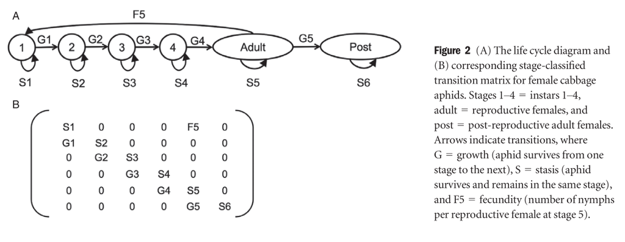

Cabbage aphid life cycle - from Cibilis-Stewart et al. 2015.

```r
# extract dominant eigenvector or stable age distribution
eigen_value$vectors[,1]
```

```
## [1] -0.76260009+0i -0.48186570+0i -0.32715194+0i -0.17659226+0i
## [5] -0.21811754+0i -0.02140257+0i
```

```r
# calculate sensitivity with popbio package
eigen_sensitivity <- sensitivity(aphids)
which.max(eigen_sensitivity)
```

```
## [1] 5
```

```r
# calculate elasticity with popbio package
eigen_elasticity <- elasticity(aphids)
which.max(eigen_elasticity)
```

```
## [1] 29
```

Ok. Now, what does this tell you about the population?

Do we get the same results if we tweak with the sensitivity value?

```r
m <- aphids

my_func = function(i, j, L) {
   old = eigen(L)[[1]][1]
   L[i, j] = L[i, j] + .05
   print(str_glue("changed: ", i, ", ", j, " difference in eigenval: ", eigen(L)[[1]][1] - old))
}

cross2(1:nrow(m), 1:ncol(m)) %>%
   transpose() %>%
   pwalk(my_func, L = m)
```

```
## changed: 1, 1 difference in eigenval: 0.00692958161406909+0i
## changed: 2, 1 difference in eigenval: 0.0101419190460572+0i
## changed: 3, 1 difference in eigenval: 0.0168587595946434+0i
## changed: 4, 1 difference in eigenval: 0.0347423155755702+0i
## changed: 5, 1 difference in eigenval: 0.0758894386805584+0i
## changed: 6, 1 difference in eigenval: 0+0i
## changed: 1, 2 difference in eigenval: 0.00431495118164515+0i
## changed: 2, 2 difference in eigenval: 0.00678077771486052+0i
## changed: 3, 2 difference in eigenval: 0.0106594489324738+0i
## changed: 4, 2 difference in eigenval: 0.0216769509505323+0i
## changed: 5, 2 difference in eigenval: 0.0452072199022009+0i
## changed: 6, 2 difference in eigenval: 0+0i
## changed: 1, 3 difference in eigenval: 0.00290775420471734+0i
## changed: 2, 3 difference in eigenval: 0.00453915711639796+0i
## changed: 3, 3 difference in eigenval: 0.00768806163845492+0i
## changed: 4, 3 difference in eigenval: 0.014646350809123+0i
## changed: 5, 3 difference in eigenval: 0.0298816624085085+0i
## changed: 6, 3 difference in eigenval: 0+0i
## changed: 1, 4 difference in eigenval: 0.00156281292123506+0i
## changed: 2, 4 difference in eigenval: 0.00242831043545166+0i
## changed: 3, 4 difference in eigenval: 0.00407219530543124+0i
## changed: 4, 4 difference in eigenval: 0.00851496405658803+0i
## changed: 5, 4 difference in eigenval: 0.0161577352532778+0i
## changed: 6, 4 difference in eigenval: 0+0i
## changed: 1, 5 difference in eigenval: 0.00191827530712141+0i
## changed: 2, 5 difference in eigenval: 0.00297217173986475+0i
## changed: 3, 5 difference in eigenval: 0.00495866317843685+0i
## changed: 4, 5 difference in eigenval: 0.0102325401346297+0i
## changed: 5, 5 difference in eigenval: 0.021685187455416+0i
## changed: 6, 5 difference in eigenval: 0+0i
## changed: 1, 6 difference in eigenval: 0.000189120801059373+0i
## changed: 2, 6 difference in eigenval: 0.000292941286016646+0i
## changed: 3, 6 difference in eigenval: 0.000487894870420114+0i
## changed: 4, 6 difference in eigenval: 0.000998833346233408+0i
## changed: 5, 6 difference in eigenval: 0.00205256591089609+0i
## changed: 6, 6 difference in eigenval: 0+0i
```

```r
# credit to Brendan Case
```

Do we get the same proportional change if we tweak the elasticity value?

```r
m <- aphids

my_func = function(i, j, L) {
   old = eigen(L)[[1]][1]
   L[i, j] = L[i, j] * 1.05
   print(str_glue("changed: ", i, ", ", j, " difference in eigenval: ", eigen(L)[[1]][1] - old))
}

cross2(1:nrow(m), 1:ncol(m)) %>%
   transpose() %>%
   pwalk(my_func, L = m)
```

```
## changed: 1, 1 difference in eigenval: 0.00217692128990055+0i
## changed: 2, 1 difference in eigenval: 0.00615699538155989+0i
## changed: 3, 1 difference in eigenval: 0+0i
## changed: 4, 1 difference in eigenval: 0+0i
## changed: 5, 1 difference in eigenval: 0+0i
## changed: 6, 1 difference in eigenval: 0+0i
## changed: 1, 2 difference in eigenval: 0+0i
## changed: 2, 2 difference in eigenval: 0.00199655666609555+0i
## changed: 3, 2 difference in eigenval: 0.00615699538155701+0i
## changed: 4, 2 difference in eigenval: 0+0i
## changed: 5, 2 difference in eigenval: 0+0i
## changed: 6, 2 difference in eigenval: 0+0i
## changed: 1, 3 difference in eigenval: 0+0i
## changed: 2, 3 difference in eigenval: 0+0i
## changed: 3, 3 difference in eigenval: 0.003098221585764+0i
## changed: 4, 3 difference in eigenval: 0.00615699538156012+0i
## changed: 5, 3 difference in eigenval: 0+0i
## changed: 6, 3 difference in eigenval: 0+0i
## changed: 1, 4 difference in eigenval: 0+0i
## changed: 2, 4 difference in eigenval: 0+0i
## changed: 3, 4 difference in eigenval: 0+0i
## changed: 4, 4 difference in eigenval: 0.004106271273421+0i
## changed: 5, 4 difference in eigenval: 0.00615699538156012+0i
## changed: 6, 4 difference in eigenval: 0+0i
## changed: 1, 5 difference in eigenval: 0.0061569953815579+0i
## changed: 2, 5 difference in eigenval: 0+0i
## changed: 3, 5 difference in eigenval: 0+0i
## changed: 4, 5 difference in eigenval: 0+0i
## changed: 5, 5 difference in eigenval: 0.0205643443302355+0i
## changed: 6, 5 difference in eigenval: 0+0i
## changed: 1, 6 difference in eigenval: 0+0i
## changed: 2, 6 difference in eigenval: 0+0i
## changed: 3, 6 difference in eigenval: 0+0i
## changed: 4, 6 difference in eigenval: 0+0i
## changed: 5, 6 difference in eigenval: 0+0i
## changed: 6, 6 difference in eigenval: 0+0i
```

```r
# credit to Brendan Case
```

References

Stubben, C.J. and Milligan, B.G. 2007. Estimating and Analyzing Demographic Models Using the popbio Package in R. Journal of Statistical Software 22:11.